# R-KNN

JeongHo LEE

## 1. 데이터 생성 ($y_{tr}$)

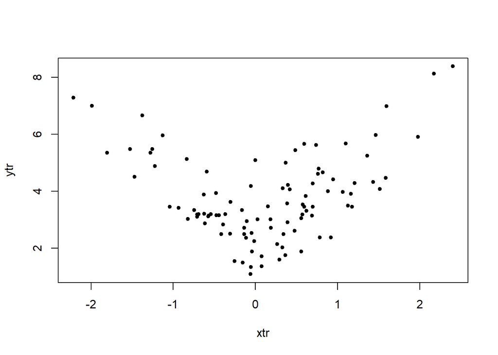

```r
set.seed(1)
xtr <- sort(rnorm(100))
ytr <- 3 + xtr^2 + rnorm(100)
library(FNN)
eval.n <- 100
eval.point = seq(-3,3, length= eval.n)
plot(xtr, ytr, pch = 20)
```

시드를 1로 두고 $x_{tr}$, $y_{tr}$를 100개 생성했다. x, y를 포인트로 찍어 plot을 그리면 위와 같다.

## 2. K-NN 적합 ($\hat y$)

```r
a  <- 100
yhat <- matrix(0, eval.n, a)
for(j in 1:a){
  idx.mat <- knnx.index(xtr, eval.point , k = j)
  for (i in 1:eval.n){
    yhat[i,j]<-mean(ytr[idx.mat[i,]])
  }
}
```

knnx.index를 이용해 k에 따른 $\hat y$를 구해서 yhat의 각 열에 입력했다.

## 3. 새로운 데이터 생성 ($x_{te}, y_{te}$)

```r
xte <- list()
yte <- list()
for(i in 1:10){
  set.seed(7*i+140)
  xte[[i]] <- sort(rnorm(100))
  yte[[i]] <- 3 + xte[[i]]^2 + rnorm(100)
}
```

## 4. $\sum (y_{te}-\hat y )^{2}$ 구하기

```r
xte.idx <- list()
sse <- rep(0,a)
sse.l <- list()
for(j in 1:10){
  xte.idx[[j]] <- as.numeric(cut(xte[[j]], breaks = eval.point, labels = 1:99))
  for(i in 1:a){
    sse[i] <- sum((yte[[j]]-yhat[xte.idx[[j]],i])^2)
  }
  sse.l[[j]] <- sse
}
```

이런 식으로 k에 따른 $\sum (y_{te}-\hat y )^{2}$를 각각 리스트 sse.l에 저장하였다.

## 5. k 선택하기

```r
which.k <- sapply(sse.l, which.min)
which.k
```

```
##  [1] 8 2 8 2 8 3 4 2 8 4
```

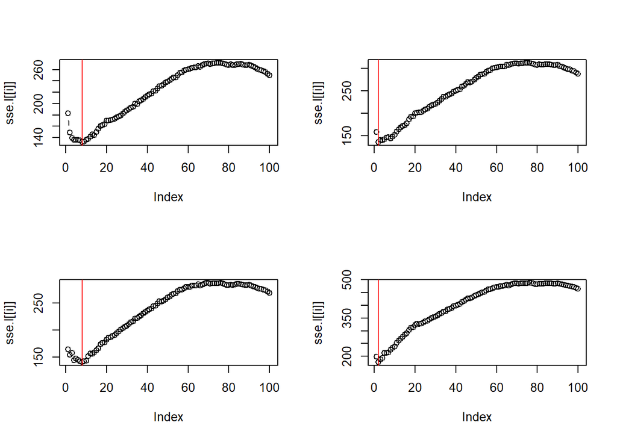

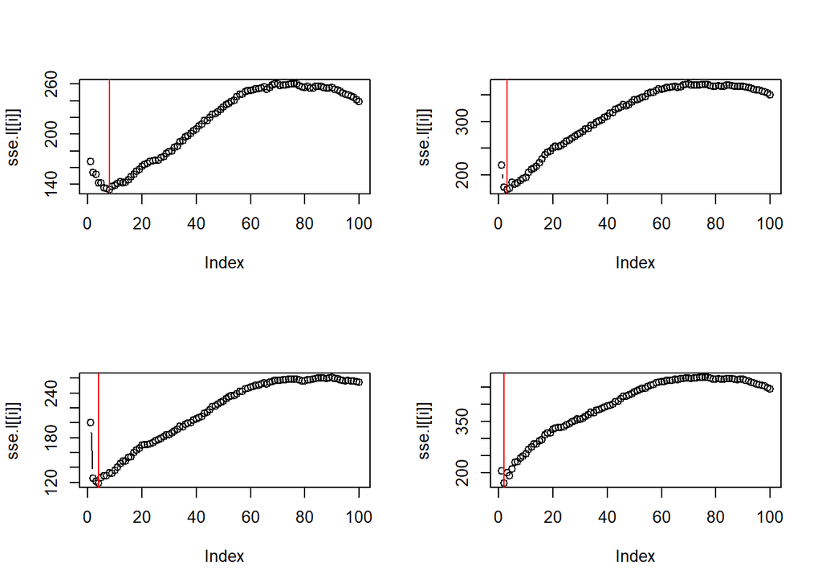

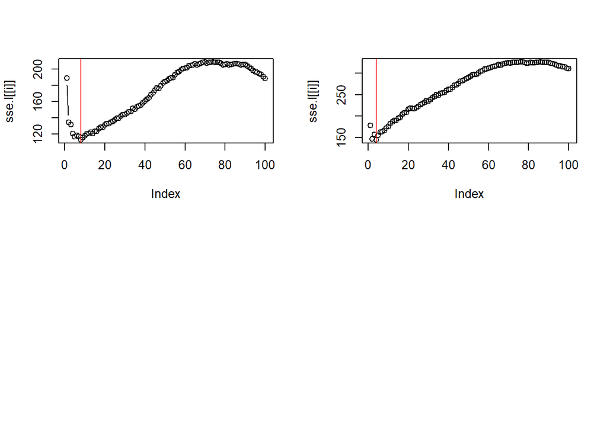

```r
par(mfrow=c(2,2))
for(i in 1:10){
  plot(sse.l[[i]], type = 'b')
  abline(v = which.min(sse.l[[i]]), col = "red")
}
```

각 시드별로 $\sum (y_{te}-\hat y )^{2}$ 제곱합 값이 최소인 k를 구하면, 순서대로 8, 2, 8, 2, 8, 3, 4, 2, 8, 4로 8이 4번, 2가 3번, 4가 2번 3이 한 번 나왔다.

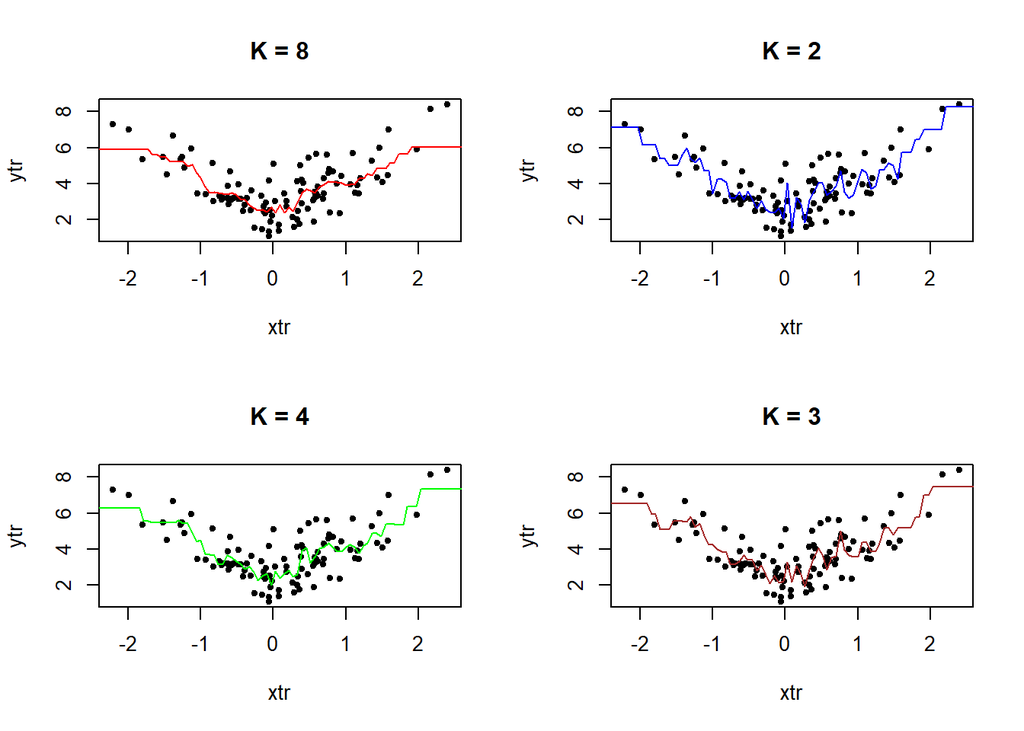

```r
par(mfrow=c(2,2))
plot(xtr, ytr, main = "K = 8", pch = 20)
lines(eval.point , yhat[ ,8], type= 'l', lty = 1, col = 'red')

plot(xtr, ytr, main = "K = 2", pch = 20)
lines(eval.point , yhat[ ,2], type= 'l', lty = 1, col = 'blue')

plot(xtr, ytr, main = "K = 4", pch = 20)
lines(eval.point , yhat[ ,4], type= 'l', lty = 1, col = 'green')

plot(xtr, ytr, main = "K = 3", pch = 20)
lines(eval.point , yhat[ ,3], type= 'l', lty = 1, col = 'brown')
```

각 K에 따른 $\hat y$의 그래프와 KNN으로 $\hat y$를 구하는데 썼던 $x_{tr}$, $y_{tr}$의 plot과 함께 비교해보면 위와 같고, 시행의 결과로 모형이 가장 좋은 k는 8이라고 선택할 수 있겠다.